### Методы статистической обработки информации

## Практика 1. Моделирование и описательная статистика

#### Выполнил Глушков Егор Александрович, гр. 20М.04-мм

Варианты №4, 7

#### №7.Равномерное распределение U(a, b)

$u(x|a=1,b=3) = \frac{1}{b-a}, a \leq x \leq b$

Моделируем данные по заданным параметрам $a=1,\;b=3$

```r
library(moments)

N <- 1500
a <- 1; b <- 3
X <- runif(n=N, min=a, max=b)
```

На модельных данных строим гистограмму

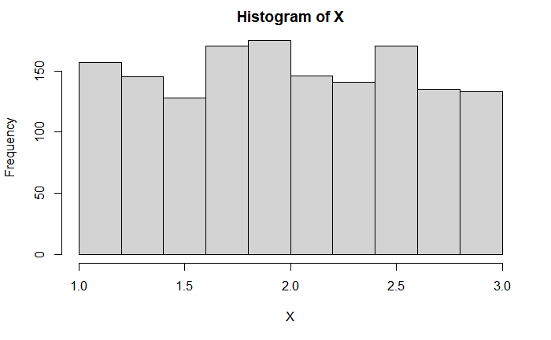

```r
hist(X)
```

### Описательная статистика

Находим матожидание, дисперсию, стандартное отклонение, ошибку среднего и сравниваем с гипотетическими параметрами

```r
expectation <- c(mean(X), (a + b)/2)
variance <- c(sd(X)^2, (b - a)^2 / 12)
st_dev <- c(sd(X), sqrt(variance[2]))
err <- c(st_dev[1] / sqrt(N), st_dev[2] / sqrt(N))

df1 <- data.frame(expectation, variance, st_dev, err, row.names = c("simulated", "hypothetical")); df1
```

|  | expectation | variance | st_dev | err |
| --- | --- | --- | --- | --- |
| simulated | 1.987216 | 0.3205567 | 0.5661773 | 0.01461863 |
| hypothetical | 2.000000 | 0.3333333 | 0.5773503 | 0.01490712 |

Находим медиану, минимум, максимум, размах

```r
c(median=median(X), min=min(X), max=max(X), R=max(X)-min(X))
```

```
  median      min      max        R
1.976192 1.003486 2.999454 1.995968
```

Находим квартили и интерквартильный размах

```r
q <- quantile(X, probs=seq(0, 1, 0.25)); q
```

```
      0%      25%      50%      75%     100%
1.003486 1.522355 1.976192 2.472107 2.999454
```

```r
Q <- q[4] - q[2]; unname(Q)
```

```
[1] 0.9497523
```

```r
c(q25<-qunif(0.25, min=a, max=b), q75<-qunif(0.75, min=a, max=b), intqR=q75-q25)
```

```
            intqR
  1.5   2.5   1.0
```

Центральные моменты 2-4 порядков по формуле и через библиотеку [совпадают]

```r
m2 <- moment(X, order=2, central=TRUE)
m3 <- moment(X, order=3, central=TRUE)
m4 <- moment(X, order=4, central=TRUE)
c(mean((X-mean(X))^3), m3)
```

```
[1] 1.990554e-06 1.990554e-06
```

```r
c(mean((X-mean(X))^4), m4)
```

```
[1] 0.191486 0.191486
```

Подсчет коэффициентов асимметрии и эксцесса по формулам и через библиотеку [совпадают]

```r
print(paste("skewness: ", m3 / m2 ^ 1.5, " (formula), ", skewness(X), " (lib)"))
```

```
[1] "skewness:  1.09787062159349e-05  (formula),  1.09787062159349e-05  (lib)"
```

```r
print(paste("kurtosis: ", m4 / m2 ^ 2 - 3, " (formula), ", kurtosis(X) - 3, " (lib; corrected)"))
```

```
[1] "kurtosis:  -1.13402214994181  (formula),  -1.13402214994181  (lib; corrected)"
```

```r
gamma1 <- 0
gamma2 <- - 6/5
print(paste("excess sk and kur: ", gamma1, gamma2, " (by formulae)"))
```

```
[1] "excess sk and kur:  0 -1.2  (by formulae)"
```

Характеристики асимметрии и эксцесса в целом соответствуют форме заданного распределения.

### Оценка параметров

#### Метод моментов

Приравниваем выборочные моменты к соответствующим моментам распределения (при 2 неизвестных параметрах, т.е. используем 2 момента): $\alpha_1 = \frac{a+b}{2}$ приравниваем к $\overline{x}$, $\mu_2 = \frac{(b-a)^2}{12}$ приравниваем к $m_2 = \sigma^2$. Получаем $a_{mm} = \overline{x} - \sqrt{3} \sigma$, $b_{mm} = \overline{x} + \sqrt{3} \sigma$

```r
a. <- mean(X) - sqrt(3) * sd(X)
b. <- mean(X) + sqrt(3) * sd(X)
c(a.=a., b.=b.)
```

```
      a.       b.
1.006569 2.967864
```

Моделируем исследуемое распределение с теоретическими и с оценочными (по методу моментов) параметрами. Строим график

```r
xx. <- runif(1500, min=a., max=b.)

hist(X, freq=FALSE, main="Method of moments")
lines(density(X), col=2)
```

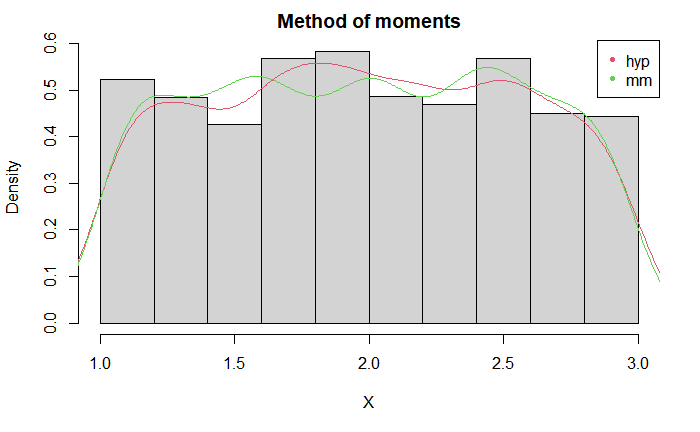

```r
lines(density(xx.), col=3)
legend('topright', c("hyp","mm"), pch=20, col=c(2,3))
```

#### Метод максимального правдоподобия

Оценки параметров по методу максимального правдоподобия

```r
Func.prob.log <- function(x) - sum(dunif(X, min = x[1], max = x[2], log = TRUE))
res <- optim(c(0.97, 3.1), Func.prob.log) # 0.9, 3.1 as initial values
a.. <- res$par[1]; b.. <- res$par[2];
c(a..=a.., b..=b..)
```

```
     a..      b..
1.003486 2.999454
```

Построим график со сравнением теоретического распределения с распределениями, построенными по параметрам, полученным в методах моментов (mm) и максимального правдоподобия (mle)

```r
xx.. <- runif(1500, min=a.., max=b..)

hist(X, freq=FALSE, main="MM, MLE")
lines(density(X), col=2)
```

```r
lines(density(xx.), col=3)
lines(density(xx..), col=4)
```

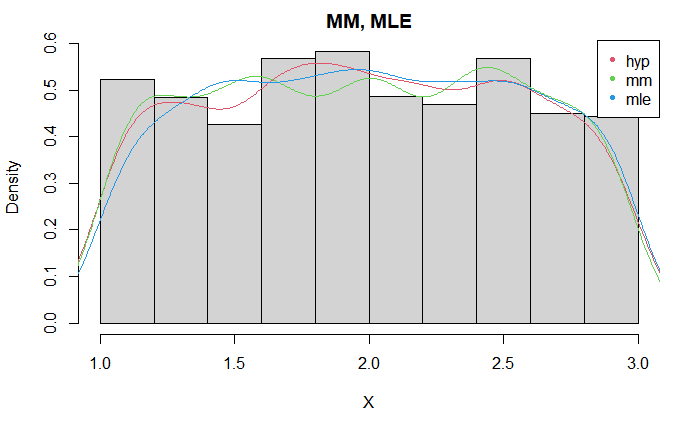

```r
legend('topright', c("hyp","mm", "mle"), pch=20, col=c(2,3,4))
```

Заметим, что оценки, полученные как по методу моментов, так и по методу максимального правдоподобия, достаточно близки к теоретическим. Для получения более точных оценок следует увеличить объем моделируемых данных

### Проверка согласия эмпирического и теоретического распределения по критерию хм-квадрат Пирсона

```r
# эмпирические частоты
h <- hist(X, plot=FALSE)

# гипотетические частоты
p.i <- sapply(seq(length(h$breaks)-1) + 1, function(i) punif(h$breaks[i], min=a, max=b) - punif(h$breaks[i-1], min=a, max=b))
p.i[1] <- punif(h$breaks[2], min=a, max=b)
p.i[length(p.i)] <- 1 - punif(h$breaks[length(h$breaks) - 1], min=a, max=b)
sum(p.i) # должно быть равно 1
```

```
[1] 1
```

Проверка условия $np_i \geq 5$ (для применения критерия согласия Пирсона)

```r
tab <- cbind(h$counts, length(X) * p.i); tab
```

```
      [,1] [,2]
 [1,]  157  150
 [2,]  145  150
 [3,]  128  150
 [4,]  170  150
 [5,]  175  150
 [6,]  146  150
 [7,]  141  150
 [8,]  170  150
 [9,]  135  150
[10,]  133  150
```

Наблюдаемое значение статистики $\chi^2$

```r
chi2 <- sum(apply(tab, 1, function(x) (x[1] - x[2])^2 / x[2])); chi2
```

```
[1] 17.29333
```

```r
alpha <- 0.05
p_value <- 1 - pchisq(chi2, nrow(tab) - 2 - 1);
print(paste("p_value", round(p_value, 3), sep=" = "))
```

```
[1] "p_value = 0.016"
```

```r
if (p_value > alpha) print(paste("The hypothesis of the agreement of the empirical distribution with the theoretical one is not rejected with the significance level alpha", alpha, sep="=")) else print("The hypothesis of the agreement of the empirical distribution with the theoretical one is rejected")
```

```
[1] "The hypothesis of the agreement of the empirical distribution with the theoretical one is rejected"
```